# HW 3

# Problem 1

```r
x <- c(-.86, -.3, -.05, .73)
n <- rep(5, 4)
y <- c(0, 1, 3, 5)
```

The posterior is described in $(3.15)$ and we set the following prior
$$(\alpha, \beta) \sim \text{N}\left(\begin{pmatrix} 0 \\ 10
\end{pmatrix}, \begin{pmatrix} 4 & 10 \\ 10 & 100\end{pmatrix} \right).$$
As we can not simplify the posterior, we will not write down the formula here, please use $(3.15)$ for reference. Following is the sampling procedure. We will try to replicate all the figures in section $3.7$.

```r
library(mvtnorm)
mu <- c(0, 10)
Sig <- matrix(c(4, 10, 10, 100), 2, 2)

link <- function(x) {
  1/(1+exp(-x))
}

log_posterior <- function(alpha, beta) {
  # x,n,y are given and fixed
  par <- c(alpha, beta)
  dmvnorm(par, mean=mu, sigma=Sig, log=T) + sum(log(link(par[1]+par[2]*x)^y*(1-link(par[1]+par[2]*x))^(n-y)))
}

iter <- 1e5
res <- matrix(nrow=iter+1, ncol=2)
res[1, ] <- c(0, 10) # init
for (i in 1:iter) {
  temp_alpha <- rnorm(1, res[i, 1], 2) # proposal
  log_ratio <- log_posterior(temp_alpha, res[i, 2]) -
    log_posterior(res[i, 1], res[i, 2]) +
    dnorm(temp_alpha, res[i, 1], 2, log=T) -
    dnorm(res[i, 1], temp_alpha, 2, log=T)
  temp_log_U <- log(runif(1))
  if (temp_log_U <= log_ratio) {
    res[i+1, 1] <- temp_alpha
  } else {
    res[i+1, 1] <- res[i, 1]
  }

  temp_beta <- rnorm(1, res[i, 2], 10) # proposal
  log_ratio <- log_posterior(res[i+1, 1], temp_beta) -
    log_posterior(res[i+1, 1], res[i, 2]) +
    dnorm(temp_beta, res[i, 2], 10, log=T) -
    dnorm(res[i, 2], temp_beta, 10, log=T)
  temp_log_U <- log(runif(1))
  if (temp_log_U <= log_ratio) {
    res[i+1, 2] <- temp_beta
  } else {
    res[i+1, 2] <- res[i, 2]
  }
}
```

```r
library(ggplot2)
xgrid <- seq(-2, 4, .01)
ygrid <- seq(0, 30, .05)
z <- matrix(nrow=length(xgrid), ncol=length(ygrid))
for (i in 1:length(xgrid)) {
  for (j in 1:length(ygrid)) {
    z[i, j] <- exp(log_posterior(xgrid[i], ygrid[j]))
  }
}
```

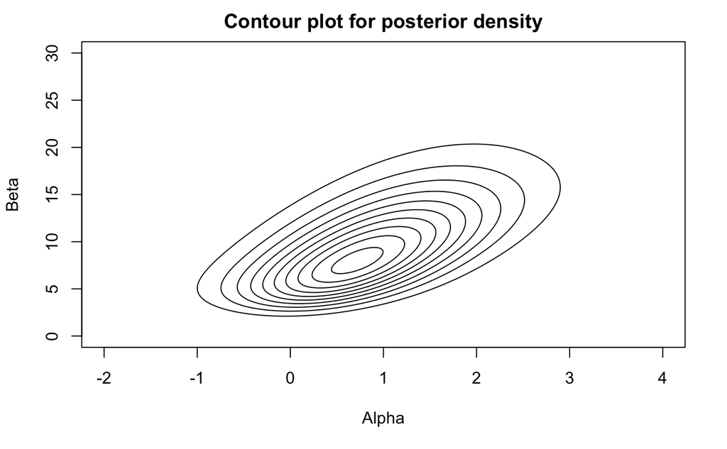

```r
contour(x=xgrid, y=ygrid, z=z, drawlabels=F,
        main='Contour plot for posterior density',
         xlab='Alpha', ylab='Beta')
```

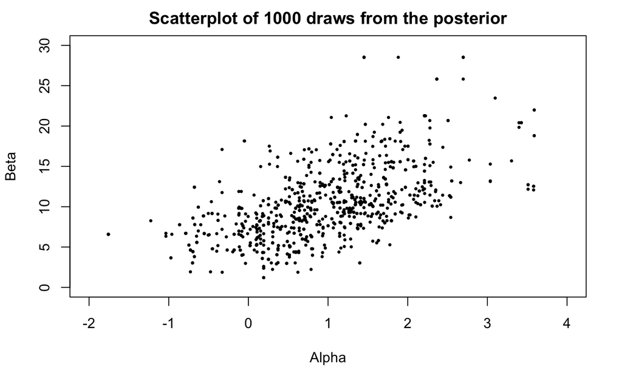

```r
plot(tail(res[, 1], 1000), tail(res[, 2], 1000),
     xlim=c(-2, 4), ylim=c(0, 30), pch=16, cex=.5,
     main='Scatterplot of 1000 draws from the posterior',
     xlab='Alpha', ylab='Beta')
```

```r
#LD50
res <- res[-c(1:1000), ] # burn-in
ld50 <- -res[, 1]/res[, 2]
ld50 <- ld50[res[, 2] > 0] #conditional on beta > 0

hist(ld50, breaks=50)
```

[output not shown]

Comparing to the uniform prior, this normal prior allow you to specify the location of the parameters with your existing knowledge.

# Problem 2

Suppose sample $(x_i, n_i, y_i)$, $i=1,...,k$ satisfies three assumptions

$$\begin{align*}
& (1) \quad x_i \neq x_j \quad \forall i,j, \\
& (2) \quad k > 1,\\
& (3) \quad 0 < y_i < n_i \quad \forall i.
\end{align*}$$

The first assumption can always be achieved because if $\exists i,j$ such that $x_i = x_j$, then we can define $y^*=y_i + y_j$, $n^*=n_i+n_j$, $x^*=x_i=x_j$ and drop $(x_i, n_i, y_i)$ and $(x_j, n_j, y_j)$.

We will show that the posterior is proper under these assumptions. With uniform prior on $\alpha$ and $\beta$, the posterior is
$$\begin{align}
p(\alpha, \beta | x, n, y) &\propto p(\alpha, \beta) p(y | \alpha, \beta, x, n) \\
&\propto \prod_{i=1}^{k} \left(\frac{1}{1+\exp(-\alpha-\beta x_i)}\right)^{y_i}\left(1-\frac{1}{1+\exp(-\alpha-\beta x_i)}\right)^{n_i-y_i}.
\end{align}$$

To check whether it is proper, we show that
$$\begin{align}
\int p(\alpha, \beta | x, n, y) d\alpha d\beta &\propto \int \prod_{i=1}^{k} \left(\frac{1}{1+\exp(-\alpha-\beta x_i)}\right)^{y_i}\left(1-\frac{1}{1+\exp(-\alpha-\beta x_i)}\right)^{n_i-y_i} d\alpha d\beta\\
&\leq \int \prod_{i=1}^{2} \left(\frac{1}{1+\exp(-\alpha-\beta x_i)}\right)^{y_i}\left(1-\frac{1}{1+\exp(-\alpha-\beta x_i)}\right)^{n_i-y_i} d\alpha d\beta\\
&= \int \prod_{i=1}^{2} {p_i}^{y_i} (1-p_i)^{n_i-y_i} |\text{det}(d \phi)(p_1, p_2)| d p_1 d p_2,
\end{align}$$
where $\phi: (p_1, p_2) \mapsto \left(\frac{x_2}{x_2 - x_1} \text{logit}(p_1) - \frac{x_1}{x_2-x_1} \text{logit}(p_2), \frac{\text{logit}(p_1) - \text{logit}(p_2)}{x_2 - x_1} \right)$ is the inverse function of $\varphi: (\alpha, \beta) \mapsto \left(\frac{1}{1+\exp(-\alpha-\beta x_1)}, \frac{1}{1+\exp(-\alpha-\beta x_2)} \right)$. The logit function is defined as $\log(x/(1-x))$. The second line is because $p_i \in (0,1)$ for all $i$ and all $\alpha,\beta$. Please note that this is only possible when we don’t have duplicate $x$ and $k \geq 2$.

Direct calculation gives
$$|\text{det}(d \phi)(p_1, p_2)| = \left|\text{det} \begin{pmatrix} \frac{x_2}{x_2 - x_1}\frac{1}{p_1(1-p_1)} & -\frac{x_1}{x_2-x_1}\frac{1}{p_2(1-p_2)} \\ -\frac{1}{x_2-x_1}\frac{1}{p_1(1-p_2)} & \frac{1}{x_2-x_1}\frac{1}{p_2(1-p_2)}
\end{pmatrix} \right| = \left|\frac{1}{x_2-x_1} \frac{1}{p_1(1-p_1)} \frac{1}{p_2(1-p_2)} \right|,$$
and above integral is just
$$\begin{align}
& \quad\left|\frac{1}{x_2-x_1}\right| \int \prod_{i=1}^2 {p_i}^{y_i} (1-p_i)^{n_i-y_i} \frac{1}{p_1(1-p_1)} \frac{1}{p_2(1-p_2)} d p_1 d p_2\\
&\propto \left|\frac{1}{x_2-x_1}\right| < \infty,
\end{align}$$
because we form the p.d.f. of two independent Beta random variables $\text{Beta}(y_1, n_1-y_1)$ and $\text{Beta}(y_2, n_2-y_2)$ in the integral (assumption $(3)$ ensures that those are proper Beta random variables).

This answer is inspired by https://stats.stackexchange.com/questions/390993/verifying-a-posterior-is-proper. The assumption $0 < y_i < n_i$ for all $i$ could be replaced by a weaker form $0 < \sum_{i=1}^k y_i < \sum_{i=1}^k n_i$ as pointed out by Christian Robert but it seems that in above proof we can not replace it.

# Problem 3

```r
y <- c(-2, -1, 0, 1.5, 2.5)

temp <- function(theta) {
  1/pi^5/(1+(y[1]-theta)^2)/(1+(y[2]-theta)^2)/(1+(y[3]-theta)^2)/
    (1+(y[4]-theta)^2)/(1+(y[5]-theta)^2)
}
const <- integrate(temp, -100, 100)$value # Normalizing constant for the posterior

posterior <- function(theta) {
  prod(1/pi/(1+(y-theta)^2)) / const
}
```

## Plot the posterior density

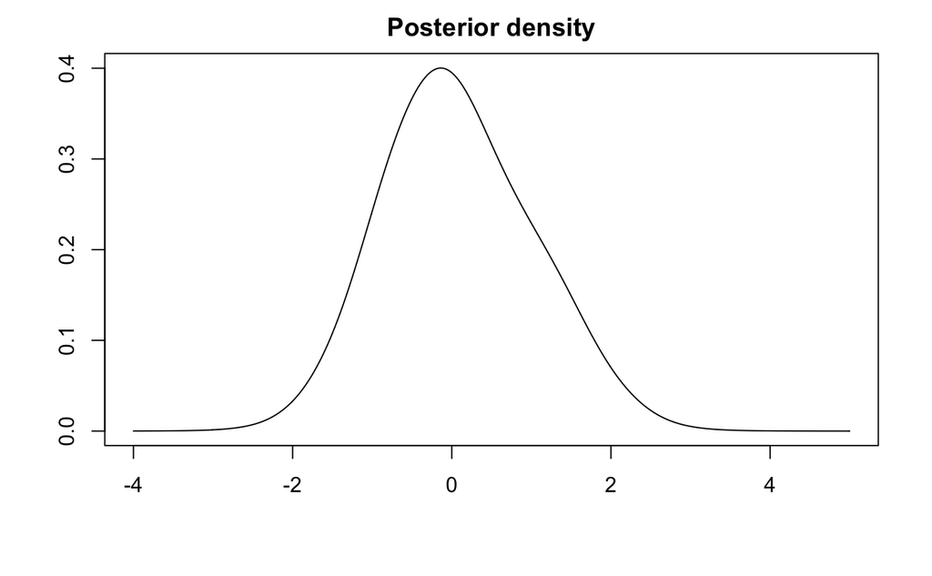

```r
grid <- seq(-4, 5, .01)
z <- c()
for (x in grid) z <- c(z, posterior(x))
plot(grid, z, type='l', main='Posterior density', xlab='', ylab='')
```

## Derivatives

The log posterior is
$$l(\theta | y ) = - \sum_{i=1}^n \log\left(1+(y_i -\theta)^2\right),$$
and the derivatives are
$$\begin{align}
\frac{d \; l(\theta | y )}{d \theta} &= \sum_{i=1}^n \frac{2(y_i -\theta)}{1+(y_i + \theta)^2},\\
\frac{d^2 \; l(\theta | y )}{d \theta^2} &= \sum_{i=1}^n \frac{2(y_i - \theta)^2 -2}{\left(1+(y_i - \theta)^2\right)^2}.
\end{align}$$

## Find the posterior mode

I don’t think you can solve it by hand. Since we already have the second order derivative I think it’s better to use Newton’s method to get the solution.

```r
d1 <- function(x) {
  sum((y-x)/(1+(y-x)^2))
}

d2 <- function(x) {
  sum(((y-x)^2-1)/(1+(y-x)^2)^2)
}

iter <- 1e2
res <- rep(0, iter)
for (i in 1:iter) {
  res[i+1] <- res[i] - d1(res[i])/d2(res[i])
}
tail(res)
```

```
[1] -0.1376493 -0.1376493 -0.1376493 -0.1376493 -0.1376493 -0.1376493
```

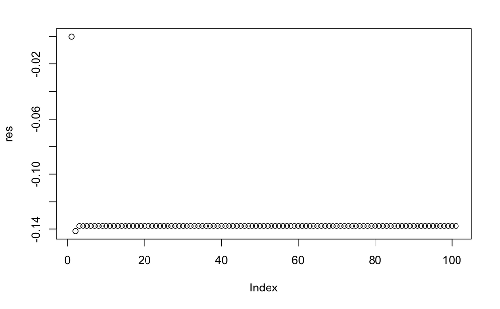

```r
plot(res)
```

## Normal approximation

Let $\hat{\theta}$ be the mode, then
$$p(\hat{\theta} | y) \approx \text{N}\left(\hat{\theta}, I^{-1}(\hat\theta)\right),$$
where $I(\hat{\theta}) = -\frac{d^2}{d \theta^2} \log p(\theta|y)\rvert_{\hat{\theta}}$.

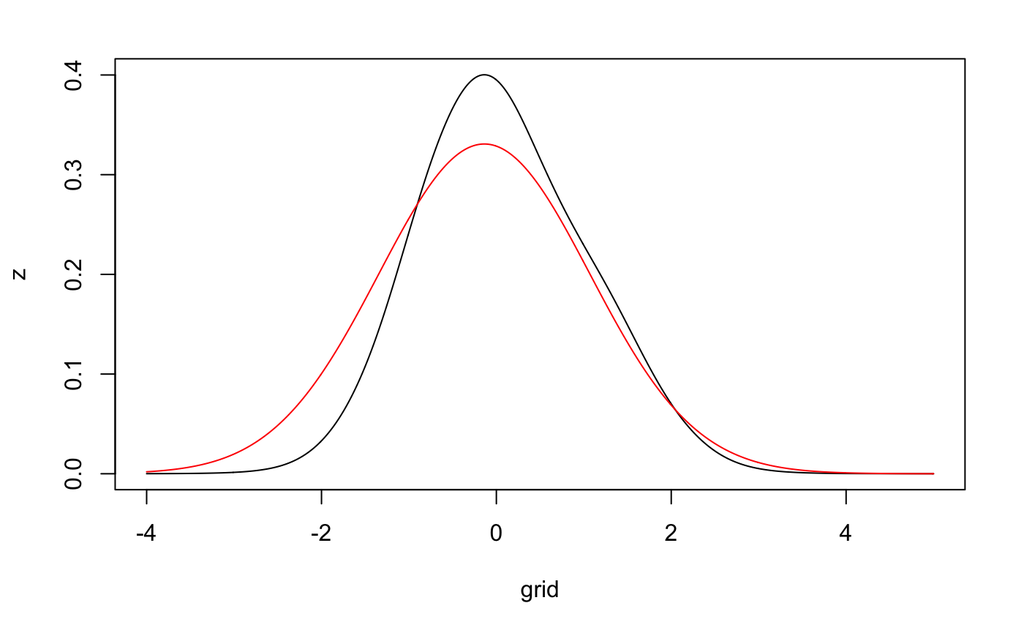

```r
mu <- tail(res, 1)
sig <- sqrt(-1/d2(mu))

grid <- seq(-4, 5, .01)
z2 <- c()
for (x in grid) z2 <- c(z2, dnorm(x, mean=mu, sd=sig))
plot(grid, z, type='l')
lines(grid, z2, col='red')
```